# Lab2 Individual Report

Isaac Tegelerr

9/8/2020

```r
library(ggplot2)
choco <- read.csv("https://raw.githubusercontent.com/xdaiISU/ds202materials/master/hwlabs/data/choco.csv")
str(choco)
```

```
## 'data.frame':    2312 obs. of  13 variables:
##  $ REF                 : int  2454 2458 2454 797 797 1015 1019 1011 1019 1011 ...
##  $ Company             : Factor w/ 541 levels "5150","A. Morin",..: 1 1 1 2 2 2 2 2 2 2 ...
##  $ Location            : Factor w/ 67 levels "Amsterdam","Argentina",..: 63 63 63 19 19 19 19 19 19 19 ...
##  $ Date                : int  2019 2019 2019 2012 2012 2013 2013 2013 2013 2013 ...
##  $ Bean_Origin         : Factor w/ 63 levels "Australia","Belize",..: 30 14 54 38 5 62 38 16 38 7 ...
##  $ Specific_Bean_Origin: Factor w/ 1436 levels "\"heirloom\", Arriba Nacional",..: 141 1435 666 1029 179 289 267 482 267 189 ...
##  $ Cocoa_Percent       : num  76 76 76 63 70 70 63 70 70 70 ...
##  $ Ingredients         : Factor w/ 21 levels "1- B","2- B,C",..: 7 7 7 14 14 14 7 14 14 14 ...
##  $ Characteristics1    : Factor w/ 450 levels "accesible","accessible",..: 81 81 311 131 430 272 403 328 81 240 ...
##  $ Characteristics2    : Factor w/ 502 levels "","\"Andes\" mint",..: 29 482 137 236 304 301 94 304 408 NA ...
##  $ Characteristics3    : Factor w/ 341 levels "","accessible",..: 115 260 29 251 NA 48 306 66 148 NA ...
##  $ Characteristics4    : Factor w/ 88 levels "acidic","apple",..: NA NA NA NA NA 66 NA 29 NA NA ...
##  $ Rating              : num  3.75 3.5 3.25 3.75 3.5 4 4 3.75 3.5 3.25 ...
```

1. How are the ratings distributed? Create both a histogram and a boxplot and describe them. Don’t forget to mention outliers, if there are any.

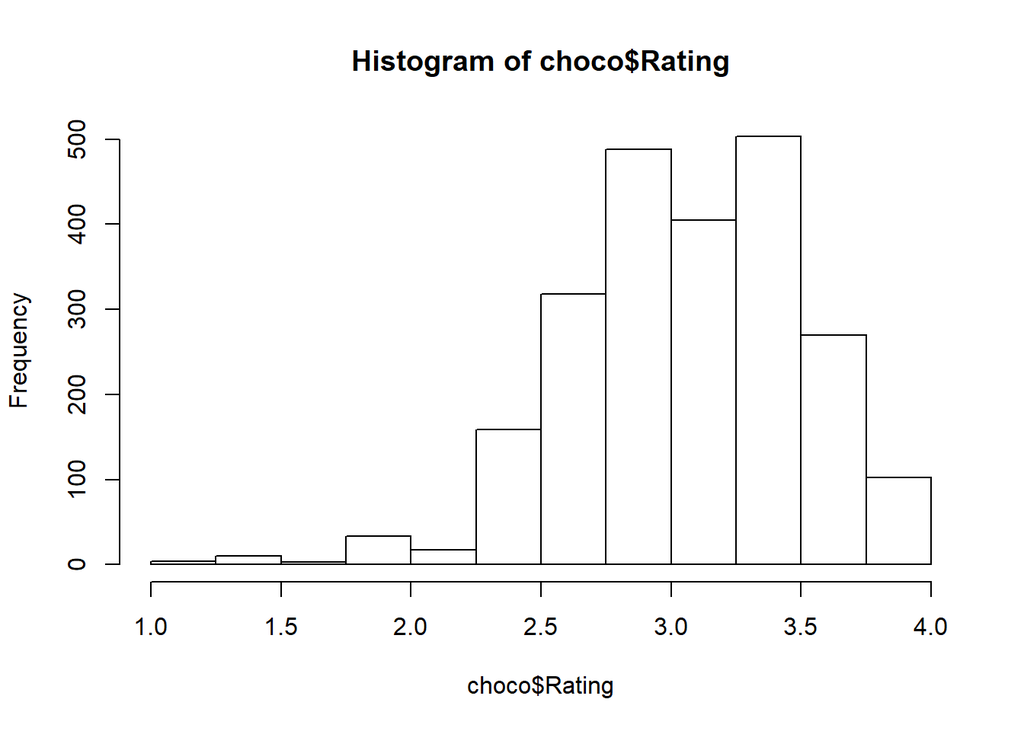

```r
hist(choco$Rating, breaks=seq(1.00, 4.00, .25))
```

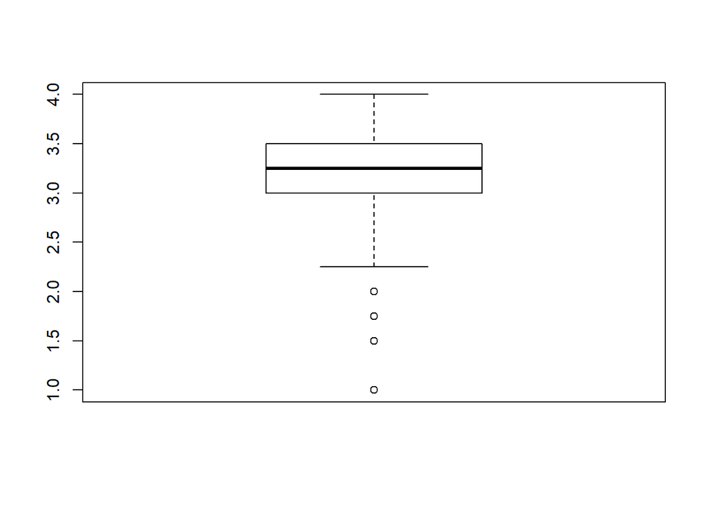

```r
boxplot(choco$Rating)
```

2. How does the number of ratings depend on the year? Draw a bar chart of the number of reports.

To do this we will add a column of 1s to the front of the data frame and then aggregate the data by the year, summing up the 1s

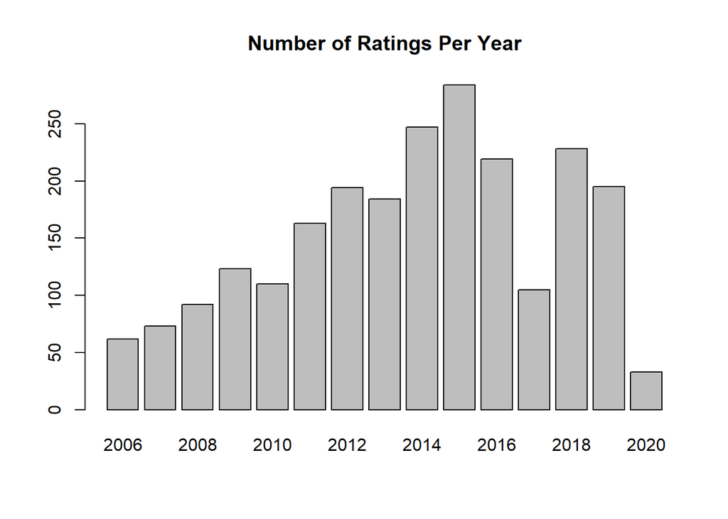

```r
choco <- cbind(count = 1, choco)
sums <- aggregate(x = choco$count, by=list(choco$Date), FUN=sum)
barplot(sums$x, names.arg = sums$Group.1, main="Number of Ratings Per Year" )
```

3. Do ratings depend on the cacao percentage of a chocolate bar? Create both numerical and graphical summaries, and explain.

```r
means <- setNames(aggregate(x = choco$Cocoa_Percent, by = list(choco$Rating), FUN=mean), c("Rating", "Cocoa_Percentage"))
means
```

```
##    Rating Cocoa_Percentage
## 1    1.00         78.25000
## 2    1.50         84.80000
## 3    1.75         90.66667
## 4    2.00         76.57576
## 5    2.25         73.29412
## 6    2.50         71.74528
## 7    2.60         70.00000
## 8    2.75         72.11672
## 9    3.00         71.69467
## 10   3.25         71.40494
## 11   3.50         71.19980
## 12   3.75         70.98704
## 13   4.00         70.77451
```

```r
maxs <-  setNames(aggregate(x = choco$Cocoa_Percent, by = list(choco$Rating), FUN=max), c("Rating", "Cocoa_Percentage"))
maxs
```

```
##    Rating Cocoa_Percentage
## 1    1.00              100
## 2    1.50              100
## 3    1.75              100
## 4    2.00              100
## 5    2.25              100
## 6    2.50              100
## 7    2.60               70
## 8    2.75              100
## 9    3.00              100
## 10   3.25               99
## 11   3.50              100
## 12   3.75               90
## 13   4.00               88
```

```r
mins <-  setNames(aggregate(x = choco$Cocoa_Percent, by = list(choco$Rating), FUN=min), c("Rating", "Cocoa_Percentage"))
mins
```

```
##    Rating Cocoa_Percentage
## 1    1.00               70
## 2    1.50               65
## 3    1.75               72
## 4    2.00               53
## 5    2.25               55
## 6    2.50               55
## 7    2.60               70
## 8    2.75               42
## 9    3.00               55
## 10   3.25               55
## 11   3.50               55
## 12   3.75               50
## 13   4.00               60
```

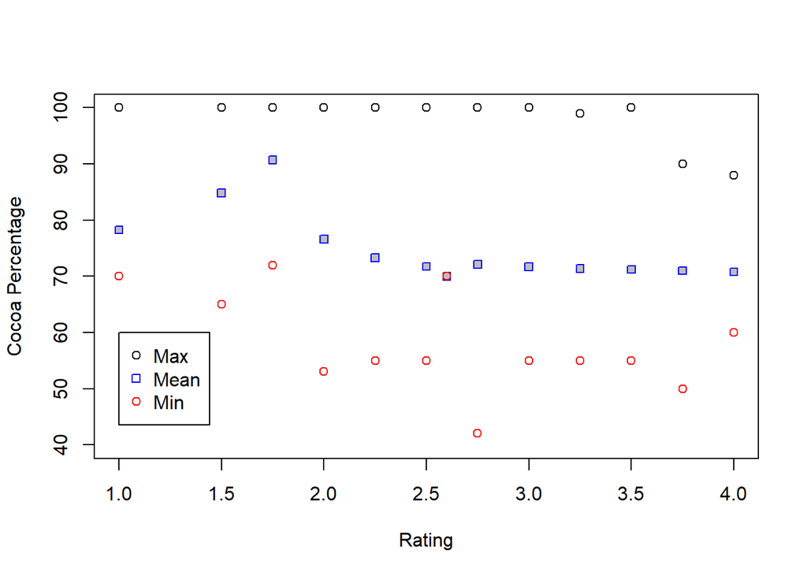

```r
plot(maxs, bg=24, ylim=c(40,100), xlab="Rating", ylab="Cocoa Percentage")
points(means, col="blue", pch=22, bg=24)
points(mins,  col="red", bg=24)
legend(1, 60, legend = c("Max", "Mean", "Min"), col=c("black", "blue", "red"), pch=c(1, 22, 1))
```

```r
cor(means$Rating, means$Cocoa_Percentage, method = c("pearson"))
```

```
## [1] -0.6994557
```

Generally speaking you can see that the lower rated chocolate bars have higher Cocoa Percentage. The somewhat negative correlation shows that as you increase in rating the cocoa percentage will decrase.

4. How do different characteristics of the chocolate compare? To elaborate, which characteristics tend to be more favorable and which ones are not? Create both numerical and graphical summaries, and explain.

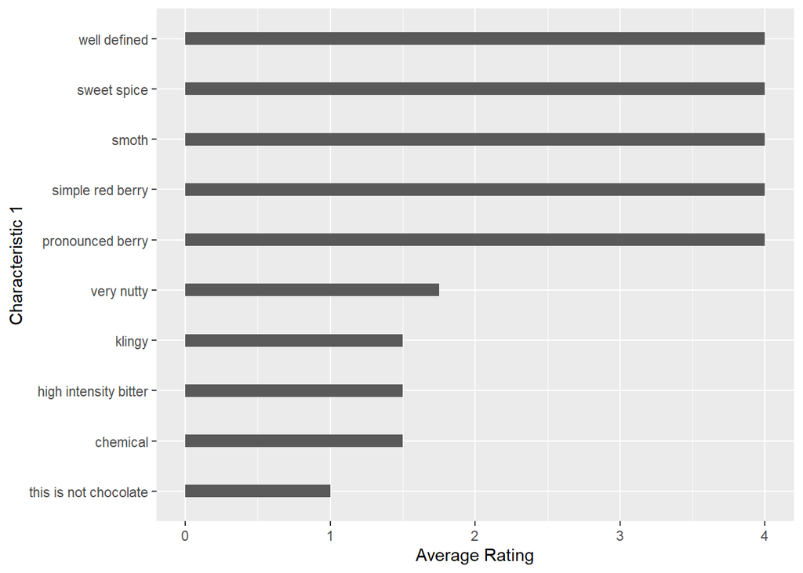

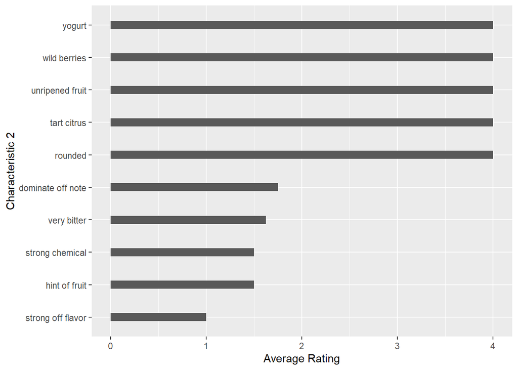

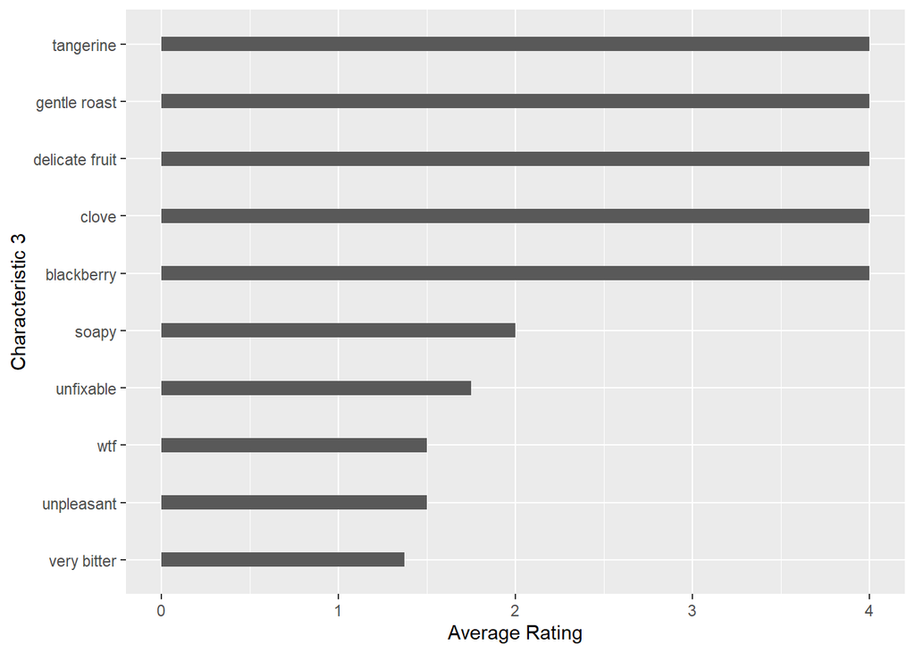

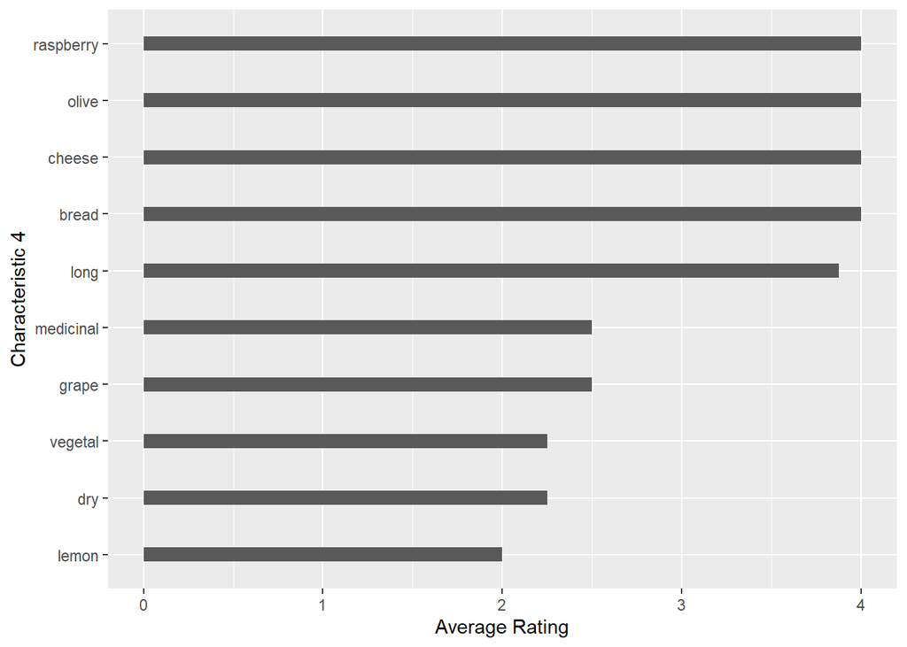

```r
ch1_mean <- aggregate(x = choco$Rating, by = list(choco$Characteristics1), FUN=mean)
ch2_mean <- aggregate(x = choco$Rating, by = list(choco$Characteristics2), FUN=mean)
ch3_mean <- aggregate(x = choco$Rating, by = list(choco$Characteristics3), FUN=mean)
ch4_mean <- aggregate(x = choco$Rating, by = list(choco$Characteristics4), FUN=mean)

ch1_ordered_mean <- ch1_mean[order(ch1_mean$x),]
ch2_ordered_mean <- ch2_mean[order(ch2_mean$x),]
ch3_ordered_mean <- ch3_mean[order(ch3_mean$x),]
ch4_ordered_mean <- ch4_mean[order(ch4_mean$x),]

ordered_means <- list(ch1_ordered_mean, ch2_ordered_mean, ch3_ordered_mean, ch4_ordered_mean)
col_names <- list("Characteristic 1", "Characteristic 2", "Characteristic 3", "Characteristic 4")


cnt <- 1
for (ordered_mean in ordered_means)
{
  top5 <- tail(ordered_mean, 5)
  bottom5 <- head(ordered_mean, 5)

  top_and_bottom <- rbind(bottom5, top5)
  top_and_bottom <- setNames(top_and_bottom, c(col_names[cnt], "Average Rating"))

  top_and_bottom[,1]<- factor(top_and_bottom[,1], levels = top_and_bottom[,1])


  p<-ggplot(data=top_and_bottom, aes(y=top_and_bottom[,1], x=top_and_bottom[,2])) + geom_bar(stat="identity", width= 0.25)  + ylab(col_names[cnt]) + xlab("Average Rating")

  print(p)

  cnt <- cnt + 1

}
```

The characteristics which indicate that it is a good chocolate are typically a fruity flavor, and a good texture. The main outliers here would be the “hint of fruit” and the “lemon” flavors that do not score very high. You can see that the average ratings for these types of flavors is high. However chemical, very bitter, and off flavors result in low ratings.

5. 2 Analyses For our two analyses we plan to look at what companies make the best chocolate and what ingredients make the worst chocolate.

See Team.Rmd for this part.